# EFA with Binary Data

Clay Ford

2022-07-28

## Simulate Data

Below I do the following to generate correlated binary data:

1. Create a 300 x 4 matrix from random uniform values ranging from [0,1]. We’ll use these as probabilities. *Each row* represents a subject. *Each column* represents a latent factor. So we have 300 subjects and 4 factors.
2. Use the values in column 1 as probabilities for generating zeroes and ones. The `rbinom()` function generates random data from a binomial distribution. Think of it as flipping 5 coins with the given probability and observing 5 results: 1 = head, 0 = tails. A result of `0, 0, 1, 1, 0` would mean two heads and three tails. If a subject has a high probability, they’re more likely to see more ones, and thus score higher on this factor.
3. Repeat step 2 for each column of the matrix (y).
4. Combine all groups into one matrix.

```r
set.seed(1234)
y <- matrix(runif(300 * 4), ncol = 4)
g1 <- sapply(y[,1], function(x)rbinom(n = 5, size = 1, prob = x)) |> t()
g2 <- sapply(y[,2], function(x)rbinom(n = 5, size = 1, prob = x)) |> t()
g3 <- sapply(y[,3], function(x)rbinom(n = 5, size = 1, prob = x)) |> t()
g4 <- sapply(y[,4], function(x)rbinom(n = 5, size = 1, prob = x)) |> t()
d <- cbind(g1, g2, g3, g4)
head(d)
```

```
##      [,1] [,2] [,3] [,4] [,5] [,6] [,7] [,8] [,9] [,10] [,11] [,12] [,13] [,14]
## [1,]    0    0    0    0    0    0    0    0    0     1     0     0     0     0
## [2,]    0    0    0    1    0    1    1    1    1     1     0     1     1     0
## [3,]    1    1    0    1    0    0    1    0    1     1     0     0     0     0
## [4,]    0    1    0    0    1    0    1    1    0     1     0     0     1     1
## [5,]    1    0    1    1    1    1    1    1    1     1     0     0     0     1
## [6,]    1    1    1    1    0    1    1    0    0     0     0     0     0     0
##      [,15] [,16] [,17] [,18] [,19] [,20]
## [1,]     0     0     1     1     1     0
## [2,]     0     0     1     1     1     1
## [3,]     0     0     0     1     1     1
## [4,]     0     1     0     0     1     1
## [5,]     1     1     1     1     0     1
## [6,]     0     0     0     0     0     0
```

## Visualize Correlation matrix

With our data simulated, let’s visualize the correlation matrix. First we calculate correlation using the `tetrachoric()` function from the psych package. Then we visualize it using `corrplot()`.

```r
library(psych)
library(corrplot)

r <- tetrachoric(d)$rho
```

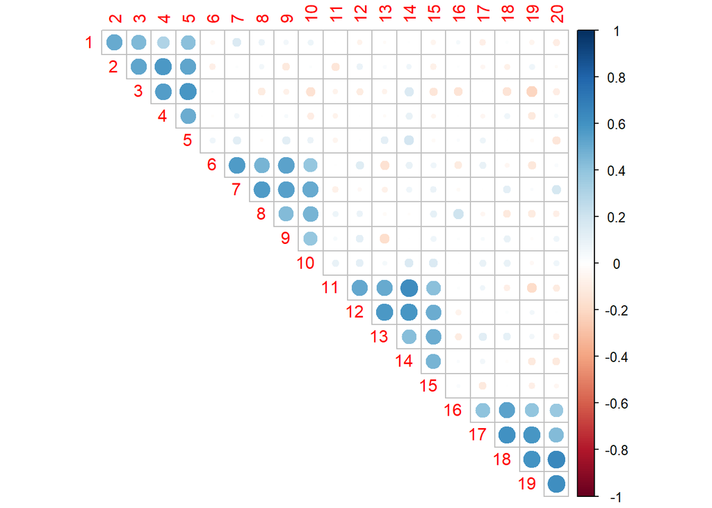

```r
corrplot::corrplot(r, type = "upper", diag = F)
```

We see we have four clumps of correlated items, as we should since we simulated the data that way.

## EFA

Now let’s try some factor analyses. First we use the default settings. It seems to run fine and recover the factors.

```r
fa_default <- fa(r = d, fm = "minres", nfactors = 4)
print(fa_default$loadings, cut = 0.3)
```

```
##
## Loadings:
##       MR1    MR2    MR3    MR4
##  [1,]                0.452
##  [2,]                0.620
##  [3,]                0.637
##  [4,]                0.568
##  [5,]                0.599
##  [6,]                       0.577
##  [7,]                       0.671
##  [8,]                       0.553
##  [9,]                       0.564
## [10,]                       0.488
## [11,]         0.598
## [12,]         0.625
## [13,]         0.585
## [14,]         0.617
## [15,]         0.503
## [16,]  0.436
## [17,]  0.564
## [18,]  0.722
## [19,]  0.646
## [20,]  0.592
##
##                  MR1   MR2   MR3   MR4
## SS loadings    1.829 1.752 1.709 1.689
## Proportion Var 0.091 0.088 0.085 0.084
## Cumulative Var 0.091 0.179 0.264 0.349
```

It would probably be better to use `cor="tet"`, which creates the correlation matrix using the `tetrachoric()` function. This results in higher loadings but the same basic result:

```r
fa_mr <- fa(r = d, fm = "minres", nfactors = 4, cor = "tet")
```

```r
print(fa_mr$loadings, cut = 0.3)
```

```
##
## Loadings:
##       MR1    MR2    MR3    MR4
##  [1,]                0.562
##  [2,]                0.756
##  [3,]                0.775
##  [4,]                0.693
##  [5,]                0.734
##  [6,]                       0.707
##  [7,]                       0.813
##  [8,]                       0.679
##  [9,]                       0.694
## [10,]                       0.605
## [11,]         0.727
## [12,]         0.758
## [13,]         0.723
## [14,]         0.749
## [15,]         0.623
## [16,]  0.544
## [17,]  0.690
## [18,]  0.869
## [19,]  0.786
## [20,]  0.717
##
##                  MR1   MR2   MR3   MR4
## SS loadings    2.711 2.621 2.562 2.543
## Proportion Var 0.136 0.131 0.128 0.127
## Cumulative Var 0.136 0.267 0.395 0.522
```

Using maximum likelihood doesn’t seem to make a difference.

```r
fa_ml <- fa(r = d, fm = "ml", nfactors = 4, cor = "tet")
```

```r
print(fa_ml$loadings, cut = 0.3)
```

```
##
## Loadings:
##       ML1    ML2    ML3    ML4
##  [1,]                0.561
##  [2,]                0.728
##  [3,]                0.782
##  [4,]                0.704
##  [5,]                0.739
##  [6,]                       0.706
##  [7,]                       0.816
##  [8,]                       0.681
##  [9,]                       0.691
## [10,]                       0.608
## [11,]         0.740
## [12,]         0.756
## [13,]         0.707
## [14,]         0.758
## [15,]         0.620
## [16,]  0.554
## [17,]  0.692
## [18,]  0.860
## [19,]  0.764
## [20,]  0.732
##
##                  ML1   ML2   ML3   ML4
## SS loadings    2.710 2.624 2.560 2.546
## Proportion Var 0.136 0.131 0.128 0.127
## Cumulative Var 0.136 0.267 0.395 0.522
```

Neither does OLS.

```r
fa_ols <- fa(r = d, fm = "ols", nfactors = 4, cor = "tet")
```

```r
print(fa_ols$loadings, cut = 0.3)
```

```
##
## Loadings:
##       [,1]   [,2]   [,3]   [,4]
##  [1,]                0.562
##  [2,]                0.756
##  [3,]                0.775
##  [4,]                0.693
##  [5,]                0.734
##  [6,]                       0.707
##  [7,]                       0.813
##  [8,]                       0.679
##  [9,]                       0.694
## [10,]                       0.605
## [11,]         0.727
## [12,]         0.758
## [13,]         0.723
## [14,]         0.749
## [15,]         0.623
## [16,]  0.544
## [17,]  0.690
## [18,]  0.869
## [19,]  0.786
## [20,]  0.717
##
##                 [,1]  [,2]  [,3]  [,4]
## SS loadings    2.711 2.621 2.562 2.543
## Proportion Var 0.136 0.131 0.128 0.127
## Cumulative Var 0.136 0.267 0.395 0.522
```

## Working with “bad” data

Let’s generate crazy 0/1 data with no correlation and see what happens.

```r
set.seed(666)
d_bad <- matrix(data = sample(0:1, size = 300 * 20, replace = TRUE),
                ncol = 20)
r2 <- tetrachoric(d_bad)$rho
```

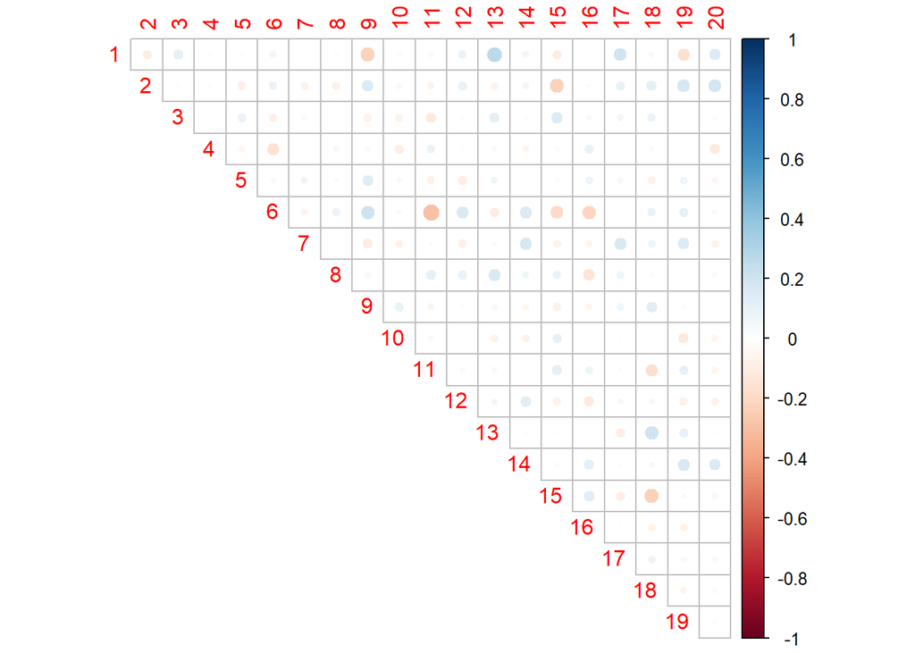

```r
corrplot::corrplot(r2, type = "upper", diag = F)
```

Amazingly, this seems to converge to something using the default correlation calculations, though of course it’s nonsense.

```r
fa2_default <- fa(r = d_bad, fm = "minres", nfactors = 4)
print(fa2_default$loadings, cut = 0.3)
```

```
##
## Loadings:
##       MR1    MR2    MR3    MR4
##  [1,]         0.644
##  [2,]                0.385
##  [3,]
##  [4,]
##  [5,]
##  [6,]  0.998
##  [7,]
##  [8,]
##  [9,]
## [10,]
## [11,]
## [12,]
## [13,]
## [14,]
## [15,]               -0.405
## [16,]
## [17,]
## [18,]                0.309
## [19,]                       0.511
## [20,]
##
##                  MR1   MR2   MR3   MR4
## SS loadings    1.095 0.651 0.545 0.483
## Proportion Var 0.055 0.033 0.027 0.024
## Cumulative Var 0.055 0.087 0.115 0.139
```

It would seem more appropriate to use `cor = "tet"` since our data is 0/1. This results in warnings about a mysterious “ultra-Heywood case”! While this seems weird and troublesome, in this case it’s probably working as intended. That’s probably a sign we’re looking for factors that don’t exist. (Warnings can be a good thing.) A Heywood case is when a uniqueness falls below 0.

```r
fa2_mr <- fa(r = d_bad, fm = "minres", nfactors = 4, cor = "tet")
```

```
## Warning in fa.stats(r = r, f = f, phi = phi, n.obs = n.obs, np.obs = np.obs, :
## The estimated weights for the factor scores are probably incorrect. Try a
## different factor score estimation method.
```

```
## Warning in fac(r = r, nfactors = nfactors, n.obs = n.obs, rotate = rotate, : An
## ultra-Heywood case was detected. Examine the results carefully
```

```r
fa2_mr$uniquenesses[fa2_mr$uniquenesses < 0]
```

```
## [1] -0.001767915
```

Reducing the number of factors to 1 eliminates the warnings, but of course this “factor” is due to noise.

```r
fa2_mr <- fa(r = d_bad, fm = "minres", nfactors = 1, cor = "tet")
```

```r
print(fa2_mr$loadings, cut = 0.3)
```

```
##
## Loadings:
##       MR1
##  [1,]
##  [2,]  0.308
##  [3,]
##  [4,]
##  [5,]
##  [6,]  0.587
##  [7,]
##  [8,]
##  [9,]
## [10,]
## [11,] -0.347
## [12,]
## [13,]
## [14,]
## [15,] -0.445
## [16,]
## [17,]
## [18,]
## [19,]
## [20,]
##
##                  MR1
## SS loadings    1.112
## Proportion Var 0.056
```